# Pagina Inicial

**Pagina Inicial**

Bem vindos alunos de Práticas Atuariais e Gestão de Riscos, vou utilizar esse site para deixar mais dinamico as tarefas e trabalhos de vocês.

**O trabalho será dividido em duas etapas:**

1. códigos no R ou no Python das tarefas
   - Tarefa 1 (Disponível)
   - Tarefa 2 (Disponível)
   - Tarefa 3 (Disponível)
   - Tarefa 4 (Disponível)
   - Tarefa 5 (Disponível)
   - Tarefa 6 (Disponível)
   - Tarefa 7 (Disponível)
2. Relatório final

Qualquer dúvida estou a disposição ! Att. Alice

email: alice.duarte@unifal-mg.edu.br

# Atualizando o R

**1. Atualizando o R com o pacote installr**

Primeiro instalem o pacote `installr` em seguida executem o comando `updateR()` para atualizar caso seja necesário, atenção nas opções do pacote.

```r
#install.packages("installr")
library("installr")
# updateR()
```

# Importando os dados do trabalho

**2. Importando os dados do trabalho**

- Faça o dowload dos dados do trabalho no link a seguir [Drive/PraticasAtuariais](https://drive.google.com/drive/u/0/folders/1a_92RYCzup_vBq7555m0IPd5ukw1gnKJ).
- Selecione no R o diretório onde estão os dados, para isso sugiro que use o comando `Ctrl + Shift + H`

```r
ativos <- read.table("ativos.txt")
inativos <- read.table("inativos.txt")
tabuas = read.csv('tabuas_de_vida.csv', h = T, sep = ';', dec = ',')
```

Vejamos agora o que tem em cada um dos bancos de dados.

**Ativos**: servidores que ainda estão ativos (trabalhando)

```r
kable(head(ativos), align = "l")
```

| Idade_participante | Salario | Tempo_contribuicao | Sexo_participante | Idade_conjuge | Sexo_conjuge | Idade_filho_01 | Idade_filho_02 |
| --- | --- | --- | --- | --- | --- | --- | --- |
| 36 | 1088.00 | 15 | F | 47 | M | 8 | 6 |
| 73 | 2068.47 | 50 | M | 68 | M | 5 | 4 |
| 35 | 1088.00 | 14 | F | 46 | M | 0 | NA |
| 50 | 1046.06 | 29 | F | 61 | M | 5 | 3 |
| 51 | 1088.00 | 31 | F | 62 | M | 7 | 3 |
| 47 | 3596.73 | 26 | M | 42 | F | 3 | 2 |

**Inativos**: Servidores que já estão em gozo do benefício

```r
kable(head(inativos), align = "l")
```

| Idade_aposentados | Beneficio | Sexo_aposentado | Idade_conjuge_aposentado | Sexo_conjuge_aposentado |
| --- | --- | --- | --- | --- |
| 91 | 4299.58 | F | 98 | M |
| 91 | 2936.59 | M | 68 | F |
| 89 | 3279.80 | F | 86 | M |
| 93 | 4505.42 | M | 70 | F |
| 78 | 4459.20 | F | 94 | M |
| 80 | 2935.38 | M | 57 | F |

**Tabuas**: Banco de tabuas fornecido pelo IBA, não são todas as tabuas mas algumas das mais usadas estão nesses dados.

```r
kable(head(tabuas))
```

| Idade | AMERICAN_EXPERIENCE | AT2000_.Suavizada.10.._FEM | AT2000_.Suavizada.10.._MAS | AT.2000_FEMALE | AT.2000_MALE | AT.49_FEMALE | AT.49_MALE | AT.83_FEMALE_.IAM. | AT.83_MALE_.IAM. | BR.EMSmt.v.2010.f | BR.EMSmt.v.2010.m | BR.EMSsb.v.2010.f | BR.EMSsb.v.2010.m | CSG.60 | CSO.41 | CSO.58 | CSO58.FEM.AGE_LAST | CSO58.FEM.AGE_NEAREST | CSO58.MAS.AGE_LAST | CSO58.MAS.AGE_NEAREST | CSO58_FEMALE | CSO58_MALE | CSO80 | GAM.71_FEMALE | GAM.71_MALE | IBGE_2006 | IBGE_2007 | IBGE_2008 | IBGE_2009 | … |
| --- | --- | --- | --- | --- | --- | --- | --- | --- | --- | --- | --- | --- | --- | --- | --- | --- | --- | --- | --- | --- | --- | --- | --- | --- | --- | --- | --- | --- | --- | --- |
| 0 | 0.15470 | 0.001615 | 0.002080 | 0.001794 | 0.002311 | 0.003210 | 0.004040 | 0.001835 | 0.002690 | 0.00128 | 0.00274 | 0.00038 | 0.00200 | 0.00832 | 0.02258 | 0.00708 | 0.003942 | 0.00620 | 0.004430 | 0.00708 | 0.00548 | 0.00633 | 0.00418 | 0.002219 | 0.003255 | 0.024891 | 0.024036 | 0.023295 | 0.022467 | … |
| 1 | 0.06349 | 0.000680 | 0.000815 | 0.000755 | 0.000906 | 0.001360 | 0.001580 | 0.000778 | 0.001053 | 0.00046 | 0.00095 | 0.00038 | 0.00069 | 0.00207 | 0.00577 | 0.00176 | 0.001540 | 0.00167 | 0.001640 | 0.00176 | 0.00094 | 0.00100 | 0.00107 | 0.000940 | 0.001274 | 0.002292 | 0.002182 | 0.002291 | 0.002152 | … |
| 2 | 0.03550 | 0.000353 | 0.000454 | 0.000392 | 0.000504 | 0.000703 | 0.000887 | 0.000402 | 0.000591 | 0.00025 | 0.00048 | 0.00020 | 0.00035 | 0.00179 | 0.00414 | 0.00152 | 0.001380 | 0.00141 | 0.001490 | 0.00152 | 0.00067 | 0.00075 | 0.00099 | 0.000486 | 0.000715 | 0.001255 | 0.001198 | 0.001188 | 0.001132 | … |
| 3 | 0.02391 | 0.000261 | 0.000367 | 0.000290 | 0.000408 | 0.000521 | 0.000715 | 0.000298 | 0.000476 | 0.00016 | 0.00030 | 0.00013 | 0.00022 | 0.00172 | 0.00338 | 0.00146 | 0.001320 | 0.00135 | 0.001430 | 0.00146 | 0.00060 | 0.00068 | 0.00098 | 0.000360 | 0.000576 | 0.000922 | 0.000880 | 0.000778 | 0.000750 | … |
| 4 | 0.01770 | 0.000209 | 0.000321 | 0.000232 | 0.000357 | 0.000419 | 0.000627 | 0.000240 | 0.000417 | 0.00012 | 0.00022 | 0.00010 | 0.00016 | 0.00165 | 0.00299 | 0.00140 | 0.001265 | 0.00129 | 0.001375 | 0.00140 | 0.00053 | 0.00061 | 0.00095 | 0.000290 | 0.000505 | 0.000699 | 0.000659 | 0.000568 | 0.000552 | … |
| 5 | 0.01360 | 0.000171 | 0.000291 | 0.000189 | 0.000324 | 0.000339 | 0.000566 | 0.000194 | 0.000377 | 0.00010 | 0.00018 | 0.00008 | 0.00013 | 0.00159 | 0.00276 | 0.00135 | 0.001215 | 0.00124 | 0.001325 | 0.00135 | 0.00047 | 0.00055 | 0.00090 | 0.000234 | 0.000456 | 0.000479 | 0.000469 | 0.000442 | 0.000432 | … |

# Tarefa 1

**Tarefa 1: Resumo dos dados**

Nesta primeira tarefa você vão conhecer melhor os nossos dados respondendo algumas peguntas, lembrem-se de incluir no relatório de vocês essa tarefa no **segundo** capítulo (reservem o primeiro capítulo para uma introdução)

- Os dados estão na pasta do drive ([Drive/PraticasAtuariais](https://drive.google.com/drive/u/0/folders/1a_92RYCzup_vBq7555m0IPd5ukw1gnKJ).), faça o download e se divirta!

**Perguntas**

```
1 . Qual a distribuição (por sexo e idade) dos servidores ativos? e dos inativos?

2. Qual o % de casais homossexuais e de heterossexuais?

3. Para os inativos, quantos são aposentados e quantos são pensionistas?

4. Além disso faça o resumo estatístico completo das variáveis dos dois bancos de dados (`summary`)
```

Lembrem-se de enviar o script do R na data da entrega da tarefa, o relatório com os resultados fica pro final da disciplina

**Sugestão para apresentar os resultados no RELATÓRIO**

**1. ESTATÍSTICA DESCRITIVA DOS DADOS**

**1.1 Ativo**

**Tabela 1. Distribuição por Faixa Etária**

|  | Feminino |  | Masculino |  |
| --- | --- | --- | --- | --- |
| Faixa Etária | nº | % | nº | % |
| 0-20 |  |  |  |  |
| 20-30 |  |  |  |  |
| 30-40 |  |  |  |  |
| 40-50 |  |  |  |  |
| 50-60 |  |  |  |  |
| 60-70 |  |  |  |  |
| 70-80 |  |  |  |  |

A tabela acima deve estar com os resultados da pergunta 1

**Tabela 2. Composição dos Casais**

|  | nº | % |
| --- | --- | --- |
| Homossexuais |  |  |
| Heterossexuais |  |  |

A tabela acima deve estar com os resultados da pergunta 2

**Tabela 3. Resumo Estatístico:**

|  | Máximo | Mínimo | Média |
| --- | --- | --- | --- |
| Idade |  |  |  |
| Salário |  |  |  |
| Tempo de Contribuição |  |  |  |
| Idade Conjuge |  |  |  |
| Idade do Filho 1 |  |  |  |
| Idade do Filho 2 |  |  |  |

A tabela acima deve estar com os resultados do summary

**1.2 Inativos**

**Tabela 4. Distribuição por Faixa Etária**

|  | Feminino |  | Masculino |  |
| --- | --- | --- | --- | --- |
| Faixa Etária | nº | % | nº | % |
| 0-20 |  |  |  |  |
| 20-30 |  |  |  |  |
| 30-40 |  |  |  |  |
| 40-50 |  |  |  |  |
| 50-60 |  |  |  |  |
| 60-70 |  |  |  |  |
| 70-80 |  |  |  |  |

A tabela acima deve estar com os resultados da pergunta 1

**Tabela 5. Composição dos Casais**

|  | nº | % |
| --- | --- | --- |
| Homossexuais |  |  |
| Heterossexuais |  |  |

A tabela acima deve estar com os resultados da pergunta 2

**Tabela 6. Situação do Benefício**

|  | nº | % |
| --- | --- | --- |
| Aposentados |  |  |
| Pensionistas |  |  |

A tabela acima deve estar com os resultados da pergunta 3

**Tabela 7. Resumo Estatístico:**

|  | Máximo | Mínimo | Média |
| --- | --- | --- | --- |
| Idade |  |  |  |
| Benefício |  |  |  |
| Idade Conjuge |  |  |  |

A tabela acima deve estar com os resultados do summary

# Tarefa 2

**Tarefa 2: Regras do RPPS**

Ainda nessa primeira etapa vamos definir quais as regras no nosso RPPS, para isso dividam-se e escolham uma das perguntas abaixo para responder (uma pergunta por dupla), sejam diretos e justifiquem a resposta

**Perguntas**

```
1. Qual tábua de vida será utilizada?

2. Qual taxa de juros?

3.  Qual a idade e o tempo de contribuição  para a aposentadoria  do sexo feminino e masculino?

4.  Qual vai ser o critério do benefício, ou seja, quanto a pessoa recebe ao se aposentar? Qual a contribuição (para os ativos)?
```

Usem o miro para esta tarefa para certificar que nenhum colega tenha escolhido o mesmo tema, coloquem no quadro o nome da dupla, o tema escolhido, a resposta e a justificativa.

**Link do miro** (Miro/Práticas)[https://miro.com/app/board/o9J_lCqezVU=/]

Após todxs preencherem o quadro já é possivel escrever o terceiro capítulo do trabalho (Bases Tecnicas)

# Tarefa 3

**Tarefa 3: Provisão Matemática de Benefícios Concedidos**

**PMBC: Provisão Matemática do Benefício Concedido**

É o valor atual dos compromissos relativo aos assistidos e pensionistas, os quais estão em gozo de benefício pelo plano. É calculada para os benefícios estruturados com base no regime financeiro de capitalização e para o grupo de servidores que já estão em gozo desse benefício, o cálculo se dá pela seguinte formula:

$$PMCB = \sum_{i=1}^{n} 13 . Beneficio . \ddot{a}^{12}_{xi}$$

Essa tarefa (3) é a **primeira etapa** do cálculo do PMBC, vamos nessa semana calcular as anuidades e posteriormente armazenar no nosso banco de dados dos servidores **inativos**, para isso sugiro que criem uma nova coluna na tábua para receber essa anuidade, como foi decidido utilizar somente uma tábua para ambos os sexos precisamos preocupar apenas com a idade dos servidores.

Para calculo das anuidades é importante seguir a tábua e a taxa de juros escolhida pela turma na tarefa anterior (Tarefa 2), importa-la e cortar a tábua. Vou deixar abaixo uma sugestão dos primeiros passos.

**OBJETIVO:** programar a anuidade vitalícia, antecipada e com fracionamento mensal para todas as idades lembrando que:

$$\ddot{a}_x^{(12)} = \ddot{a}_x - \frac{11}{24} = \left (\sum_{i=0}^{\omega-x}v^t_tp_x \right ) - \frac{11}{24}$$
1. Fazer o download da tábua escolhida https://www.ibge.gov.br/estatisticas/sociais/populacao/9126-tabuas-completas-de-mortalidade.html?=&t=downloads

1. Fixar o diretório (`Ctrl + Shitf + H`) e importar a tábua escolhida

```r
library(readxl) #pacote para ler xls

tabua <- read_xls("ambos_os_sexos.xls") #tábual escolhida
```

Observe que a tábua veio com todas as informações, como vamos calcular anuidade precisamos apenas do $q_x$ vamos estão filtrar os dados

```r
tabua <- tabua[c(5:44,61:101),c(1,2)] #selecionando as linhas e colunas que importam
names(tabua) <- c("Idade","qx") #renomeando
tabua$qx <- as.numeric(tabua$qx)
tabua$qx <- tabua$qx/1000
```

Agora é com vocês, calculem as anuidades e armazenem na propria tábua, sugiro que já programem com o fracionamento de Woolhouse (taxa de 4,5%)

```r
tabua$ax <- 0 # Criando coluna que vai receber as anuidades

kable(head(tabua))
```

| Idade | qx | ax |
| --- | --- | --- |
| 0 | 0.0119376 | 0 |
| 1 | 0.0007962 | 0 |
| 2 | 0.0005181 | 0 |
| 3 | 0.0003971 | 0 |
| 4 | 0.0003276 | 0 |
| 5 | 0.0002827 | 0 |

Depois de preenchida a coluna de anuidades salvem o resultado dessa nova tábua com o comando

```r
# write.csv(tabua_anuidade,"tabua_anuidade.csv")
```

**Dica:** Lembre-se que a pessoa de idade 0 está armazenada na coluna 1 (no R) isso deve ser considerado!

Os resultados para as primeiras idades deve ser proximo a este:

```r
res <- read.csv("tabua_anuidade")
kable(head(res))
```

| X | Idade | qx | ax |
| --- | --- | --- | --- |
| 1 | 0 | 0.0119376 | 21.28702 |
| 2 | 1 | 0.0007962 | 21.48248 |
| 3 | 2 | 0.0005181 | 21.44226 |
| 4 | 3 | 0.0003971 | 21.39410 |
| 5 | 4 | 0.0003276 | 21.34112 |
| 6 | 5 | 0.0002827 | 21.28422 |

**NÃO ESQUEÇA DE SALVAR ESSAS ANUIDADES CALCULADAS PARA AS PRÓXIMAS TAREFAS**

# Tarefa 4

**Tarefa 4: Provisão Matemática de Benefícios Concedidos - Parte 2**

### **PMBC: Provisão Matemática do Benefício Concedido**

É o valor atual dos compromissos relativo aos assistidos e pensionistas, os quais estão em gozo de benefício pelo plano. É calculada para os benefícios estruturados com base no regime financeiro de capitalização e para o grupo de servidores que já estão em gozo desse benefício, o cálculo se dá pela seguinte formula:

$$PMCB = \sum_{i=1}^{n} 13 . Beneficio . \ddot{a}^{12}_{xi}$$

Essa tarefa (4) é a **segunda etapa** do cálculo do PMBC, vamos nessa semana armazenar as anuidades calculadas no banco de dados dos servidores **inativos**, para isso sugiro que criem uma nova coluna na tábua para receber essa anuidade, e carreguem a tábua com as anuidades da tarefa 3, desta forma vocês não vão precisar calcular as anuidades novamente, apenas consulta-lás.

```r
tabua <- read.csv("tabua_anuidade.csv", row.names = 1)
# Tábua com as anuidades calculadas na tarefa anterior
```

```r
inativos$ax_12 <- 0 #coluna para receber as anuidades
inativos$PMBC <- 0 # coluna para receber o PMBC
```

Nesta tarefa vocês vão em um primeio momento preencher as anuidades de acordo com a idade do beneficiário, caso seja uma pensão (idade do aposentado `NA`) a idade deve ser do conjuje observe como o algorítimo deve funcionar no exemplo abaixo.

### Exemplo

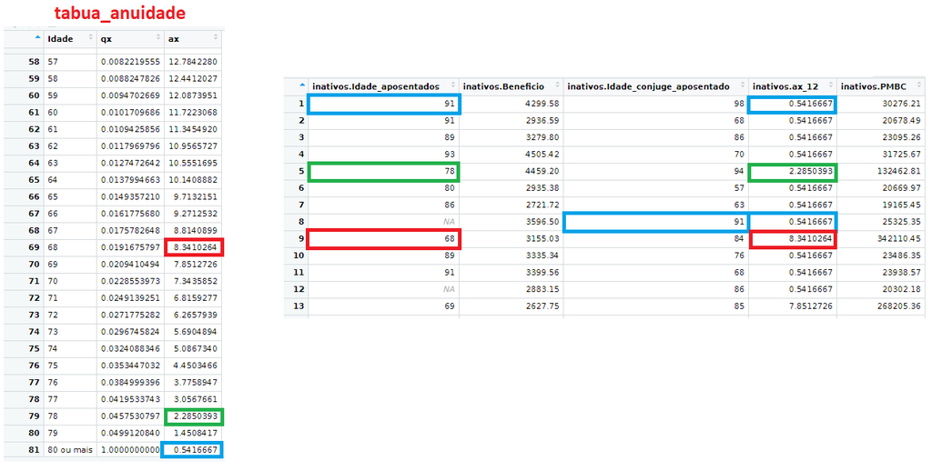

Exemplo

Em seguida deverão preencher a coluna do PMBC utilizando a equação $PMCB = \sum_{i=1}^{n} 13 . Beneficio . \ddot{a}^{12}_{xi}$

**Sugestão:** Calcule o PMBC de cada indivíduo e armazene na coluna criada e posteriormente some todos os PMBC

O resultado da tarefa é a soma de todos os PMBC indivíduais e podem ser apresentados por sexo ou por situação (Aposentado/Pensionistas) de acordo com a preferência de vocês. Vou deixar uma sugestão de tabela abaixo:

**Tabela: PMBC**

|  | Feminino | Masculino |
| --- | --- | --- |
| Aposentados |  |  |
| Pensionistas |  |  |

O PMBC Total calculado foi de: ___________

# Tarefa 5

**Tarefa 5: Provisão Matemática de Benefícios à Conceder - Parte 1**

### **PMBàC: Provisão Matemática de Benefícios à Conceder**

A provisão matemática de benefícios a conceder (PMBAC) é calculada para o grupo de servidores que ainda não estão em gozo desse benefício, ou seja, servidores **ativos**, o cálculo se dá pela seguinte formula:

$$\sum_{i=1}^{j}13 \cdot Beneficio \cdot _k|\ddot{a}^{12}_{xi} - 13 \cdot \%Salario \cdot \ddot{a}^{12}_{x:\bar{k|}}$$

No entanto, sabemos que para os servidores ativos o produto atuarial “aposentadoria” pode ser dividido em duas etapas. Antes de aposentar o beneficiário é responsável pelo pagamento do prêmio e a após atingir a idade de se aposentar ele passa a receber o benefício, sendo assim, podemos dividir a formula acima em duas etapas, são elas:

1 - Despesa com o beneficiário (pagamento do benefício da aposentadoria)

2 - Receita com o beneficiário (recebimento dos prêmios)

Nesta tarefa vamos encontrar o valor de **k**, ou seja, o tempo que falta para cada servido ativo se aposentar, utilizaremos as regras definidas na tarefa 2, são elas

```
- Mulheres: 62 anos e 15 anos de contribuição

- Homens: 65 anos e 20 anos de contribuição
```

Para esta tarefa vamos assumir que todos os nossos servidores vão contribuir durante todo o tempo, veja um exemplo:

### Exemplo

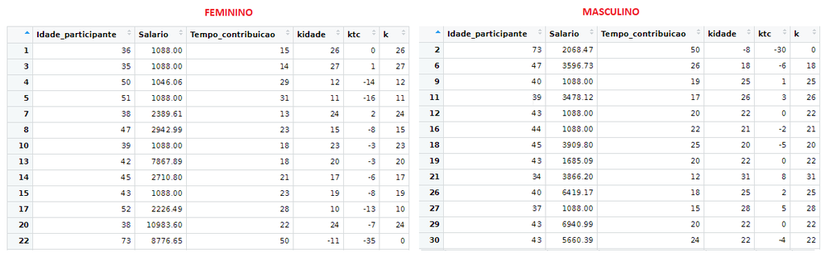

Exemplo

```r
af_p <- read.csv("ativos_fem.csv")
af_p$Sexo_participante <- "F"
knitr::kable(head(af_m))
```

```r
af_m <- read.csv("ativos_mas.csv")
knitr::kable(head(af_m))
```

| X | Idade_participante | Salario | Tempo_contribuicao | Sexo_participante | Idade_conjuge | Sexo_conjuge | Idade_filho_01 | Idade_filho_02 | kidade | ktc | k |
| --- | --- | --- | --- | --- | --- | --- | --- | --- | --- | --- | --- |
| 2 | 73 | 2068.47 | 50 | M | 68 | M | 5 | 4 | -8 | -30 | 0 |
| 6 | 47 | 3596.73 | 26 | M | 42 | F | 3 | 2 | 18 | -6 | 18 |
| 9 | 40 | 1088.00 | 19 | M | 35 | F | 2 | NA | 25 | 1 | 25 |
| 11 | 39 | 3478.12 | 17 | M | 34 | F | 5 | NA | 26 | 3 | 26 |
| 12 | 43 | 1088.00 | 20 | M | 38 | F | 5 | NA | 22 | 0 | 22 |
| 16 | 44 | 1088.00 | 22 | M | 39 | F | 5 | 2 | 21 | -2 | 21 |

*Dicas*:

1. Separe os dados por sexo
2. Crie 2 vetores, uma para armazenar o tempo que falta para aposentar pode idade e o outro por tempo de contribuição
3. O k será o maior valor desses dois vetores.

# Tarefa 6

**Tarefa 6: Provisão Matemática de Benefícios à Conceder - Parte 2**

### **PMBàC: Provisão Matemática de Benefícios à Conceder - DESPESAS**

A provisão matemática de benefícios a conceder (PMBAC) é calculada para o grupo de servidores que ainda não estão em gozo desse benefício, ou seja, servidores **ativos**, o cálculo se dá pela seguinte formula:

$$\sum_{i=1}^{j}13 \cdot Beneficio \cdot _k|\ddot{a}^{12}_{xi} - 13 \cdot \%Salario \cdot \ddot{a}^{12}_{x:\bar{k|}}$$

No entanto, sabemos que para os servidores ativos o produto atuarial “aposentadoria” pode ser dividido em duas etapas. Antes de aposentar o beneficiário é responsável pelo pagamento do prêmio e a após atingir a idade de se aposentar ele passa a receber o benefício, sendo assim, podemos dividir a formula acima em duas etapas, são elas:

1 - Despesa com o beneficiário (pagamento do benefício da aposentadoria)

2 - Receita com o beneficiário (recebimento dos prêmios)

### Despesas - Parte 2: Cálculo das anuidades e das despesas para ambos os sexos

Nessa parte do trabalho faremos o cálculo da despesa com o beneficiário dada por:

$$\sum_{i=1}^{j}13 \cdot Beneficio \cdot _k|\ddot{a}^{12}_{xi}$$

O benefício foi definido pelos colegas (Yuri e Raiane) como sendo a média das constribuições (no caso do salário) o valor será então 60% do salário + 2% para cada ano de contribuição alem do tempo definido de 15 anos para mulheres e 20 para homens.

$$\sum_{i=1}^{j}13 \cdot Salario \cdot \% ajuste \cdot _k|\ddot{a}^{12}_{xi}$$

A despesa é calculada com base no que se espera gastar com cada beneficiário. Para programar essa tarefa vamos utilizar o valor de K calculado na tarefa anterior

Esta tarefa então se resume em calcular as anuidades diferidas por k anos para cada indivíduo e em seguida calcular o ajuste.

**Sugestão:** Sempre que terminar uma tarefa salve a tarefa nos seus dados para carregar na seguinte sem precisar rodar novamente, ou use o mesmo script.

### Passo a Passo:

1. Importar bancos de dados

```r
ativosf <- read.csv("ativos_fem.csv", row.names = 1)
ativosf$Sexo_participante <- "F"
knitr::kable(head(ativosf))
```

|  | Idade_participante | Salario | Tempo_contribuicao | Sexo_participante | Idade_conjuge | Sexo_conjuge | Idade_filho_01 | Idade_filho_02 | kidade | ktc | k |
| --- | --- | --- | --- | --- | --- | --- | --- | --- | --- | --- | --- |
| 1 | 36 | 1088.00 | 15 | F | 47 | M | 8 | 6 | 26 | 0 | 26 |
| 3 | 35 | 1088.00 | 14 | F | 46 | M | 0 | NA | 27 | 1 | 27 |
| 4 | 50 | 1046.06 | 29 | F | 61 | M | 5 | 3 | 12 | -14 | 12 |
| 5 | 51 | 1088.00 | 31 | F | 62 | M | 7 | 3 | 11 | -16 | 11 |
| 7 | 38 | 2389.61 | 13 | F | 49 | M | 7 | 3 | 24 | 2 | 24 |
| 8 | 47 | 2942.99 | 23 | F | 58 | M | 5 | 3 | 15 | -8 | 15 |

```r
ativosm <- read.csv("ativos_mas.csv", row.names = 1)
knitr::kable(head(ativosm))
```

|  | Idade_participante | Salario | Tempo_contribuicao | Sexo_participante | Idade_conjuge | Sexo_conjuge | Idade_filho_01 | Idade_filho_02 | kidade | ktc | k |
| --- | --- | --- | --- | --- | --- | --- | --- | --- | --- | --- | --- |
| 2 | 73 | 2068.47 | 50 | M | 68 | M | 5 | 4 | -8 | -30 | 0 |
| 6 | 47 | 3596.73 | 26 | M | 42 | F | 3 | 2 | 18 | -6 | 18 |
| 9 | 40 | 1088.00 | 19 | M | 35 | F | 2 | NA | 25 | 1 | 25 |
| 11 | 39 | 3478.12 | 17 | M | 34 | F | 5 | NA | 26 | 3 | 26 |
| 12 | 43 | 1088.00 | 20 | M | 38 | F | 5 | NA | 22 | 0 | 22 |
| 16 | 44 | 1088.00 | 22 | M | 39 | F | 5 | 2 | 21 | -2 | 21 |

```r
tabuas = read.csv('tabua_anuidade.csv', h = T, sep = ',', dec = '.', row.names=1)
```

Observem que a tabua carregada já está com as anuidades que calculamos nas tarefas anteriores.

2. Criar a coluna que vai armazenar os resultados das anuidades (pode ser preenchida com um `for`)
3. Lembrem-se que as anuidades são diferidas e são dadas por:

$$_k|\ddot{a}^{12}_{xi} = ( \frac{1}{1+i})^{k}*_{k|}p_{xi} * \ddot{a}^{12}_{xi+k}$$

4. As anuidades nesse caso não precisam ser calculadas, apenas consultadas na tábua que fizemos anteriormente na posição $x_i + k$.
5. Calculadas as anuidades basta multiplica-las por $13 \cdot Salario$ para calcular a despesa com PMBaC.

Para o sexo feminino o resultado deve ser próximo a esse:

| X | Idade_participante | Salario | Tempo_contribuicao | Sexo_participante | Idade_conjuge | Sexo_conjuge | Idade_filho_01 | Idade_filho_02 | kidade | ktc | k | anuid_dif | pec_ben | PMBAC_Desp |
| --- | --- | --- | --- | --- | --- | --- | --- | --- | --- | --- | --- | --- | --- | --- |
| 1 | 36 | 1088.00 | 15 | F | 47 | M | 8 | 6 | 26 | 0 | 26 | 3.052788 | 1.12 | 48360.07 |
| 3 | 35 | 1088.00 | 14 | F | 46 | M | 0 | NA | 27 | 1 | 27 | 2.915959 | 1.12 | 46192.52 |
| 4 | 50 | 1046.06 | 29 | F | 61 | M | 5 | 3 | 12 | -14 | 12 | 5.895581 | 1.12 | 89793.43 |
| 5 | 51 | 1088.00 | 31 | F | 62 | M | 7 | 3 | 11 | -16 | 11 | 6.191481 | 1.14 | 99832.42 |
| 7 | 38 | 2389.61 | 13 | F | 49 | M | 7 | 3 | 24 | 2 | 24 | 3.346878 | 1.04 | 108129.37 |
| 8 | 47 | 2942.99 | 23 | F | 58 | M | 5 | 3 | 15 | -8 | 15 | 5.100419 | 1.06 | 206844.44 |

Para o sexo masculino o resultado deve ser próximo a esse:

| X | Idade_participante | Salario | Tempo_contribuicao | Sexo_participante | Idade_conjuge | Sexo_conjuge | Idade_filho_01 | Idade_filho_02 | kidade | ktc | k | anuid_dif | pec_ben | PMBAC_Desp |
| --- | --- | --- | --- | --- | --- | --- | --- | --- | --- | --- | --- | --- | --- | --- |
| 2 | 73 | 2068.47 | 50 | M | 68 | M | 5 | 4 | -8 | -30 | 0 | 5.690489 | 1.20 | 183621.46 |
| 6 | 47 | 3596.73 | 26 | M | 42 | F | 3 | 2 | 18 | -6 | 18 | 3.812282 | 1.08 | 192512.95 |
| 9 | 40 | 1088.00 | 19 | M | 35 | F | 2 | NA | 25 | 1 | 25 | 2.743786 | 1.08 | 41912.75 |
| 11 | 39 | 3478.12 | 17 | M | 34 | F | 5 | NA | 26 | 3 | 26 | 2.619739 | 1.06 | 125560.15 |
| 12 | 43 | 1088.00 | 20 | M | 38 | F | 5 | NA | 22 | 0 | 22 | 3.155109 | 1.04 | 46410.89 |
| 16 | 44 | 1088.00 | 22 | M | 39 | F | 5 | 2 | 21 | -2 | 21 | 3.306725 | 1.06 | 49576.54 |

Após calculadas as anuidades é necessário calcular o percentual do salário que corresponde ao benefício conforme as regras definidas e então calcular a despesa com PMBAC para cada indivíduo

Então a soma das Despesas com PMBAC para o sexo feminino será: ____________

Então a soma das Despesas com PMBAC para o sexo masculino será: _____________

# Tarefa 7

**Tarefa 7: Provisão Matemática de Benefícios à Conceder - Parte 3**

### **PMBàC: Provisão Matemática de Benefícios à Conceder - RECEITAS**

A provisão matemática de benefícios a conceder (PMBAC) é calculada para o grupo de servidores que ainda não estão em gozo desse benefício, ou seja, servidores **ativos**, o cálculo se dá pela seguinte formula:

$$\sum_{i=1}^{j}13 \cdot Beneficio \cdot _k|\ddot{a}^{12}_{xi} - 13 \cdot \%Salario \cdot \ddot{a}^{12}_{x:\bar{k|}}$$

No entanto, sabemos que para os servidores ativos o produto atuarial “aposentadoria” pode ser dividido em duas etapas. Antes de aposentar o beneficiário é responsável pelo pagamento do prêmio e a após atingir a idade de se aposentar ele passa a receber o benefício, sendo assim, podemos dividir a formula acima em duas etapas, são elas:

1 - Despesa com o beneficiário (pagamento do benefício da aposentadoria)

2 - Receita com o beneficiário (recebimento dos prêmios)

### RECEITA: Cálculo das anuidades e das receita para ambos os sexos

Nessa parte do trabalho faremos o cálculo da receita com o beneficiário dada por:

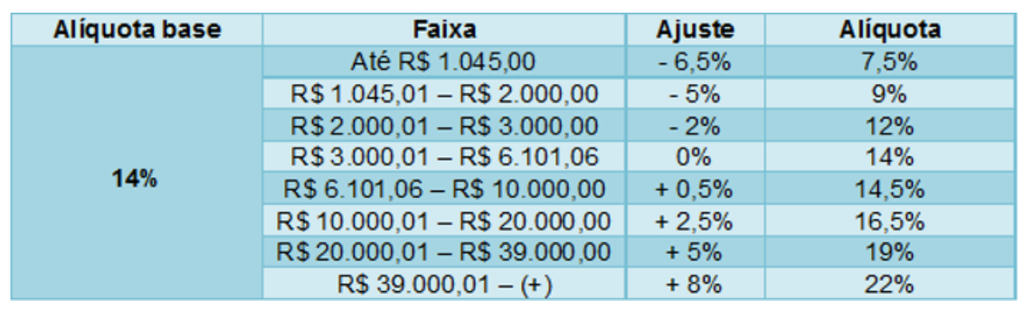

Vamos definir então a contribuição como sendo o $Salario \cdot Aliquota$, uma sugestão é criar uma coluna nos dados que tenha como resultado a aliquota de cada indivíduo

Desta forma vamos criar uma coluna no nosso banco de dados com a contribuição de cada beneficiário

A ideia é esta:

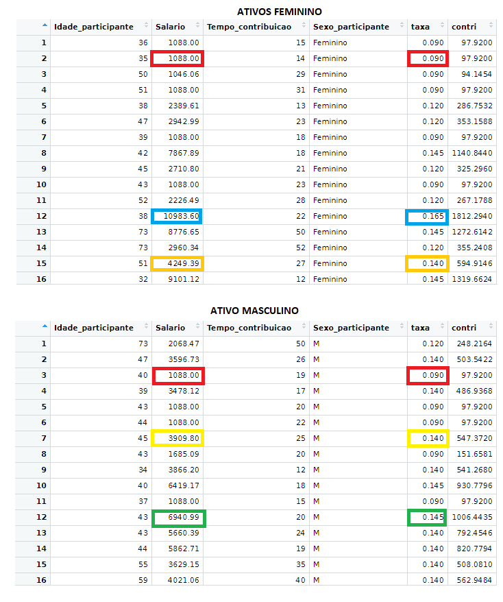

Queremos calcular

$$\sum_{i=1}^{j}13 \cdot Taxa \cdot Salário \cdot \ddot{a}^{12}_{xi:k}$$

Vamos então programar a anunidade temporária

1. Carregar a tábua

```r
tabuas = read.csv('tabua_anuidade.csv', sep = ',', dec = '.', h = T, row.names=1)
```

Observem que a tabua carregada já está com as anuidades que calculamos nas tarefas anteriores.

2. Criar a coluna que vai armazenar os resultados das anuidades (pode ser preenchida com um `for`)
3. Lembrem-se que as anuidades temporárias podem ser calculadas usando a relação

$$\ddot{a}^{12}_{xi:k} = \ddot{a}^{12}_{xi} - \ddot{a}^{12}_{xi+k}$$

$$\sum_{i=1}^{j}13 \cdot Taxa \% Salário \cdot (\ddot{a}^{12}_{xi} - \ddot{a}^{12}_{xi+k})$$

- Deve ficar próximo de:

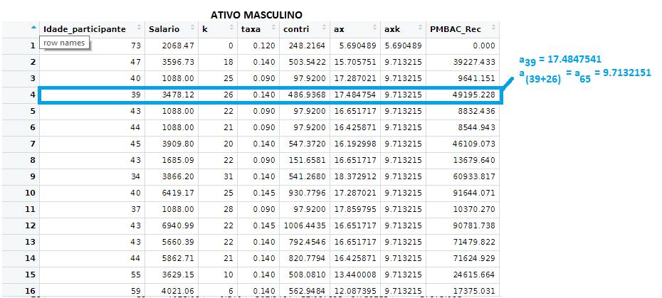

Feito o Calculo do PMBAC_Receita por indíviduo basta somar todos eles por sexo para ter o resultado da segunda parte do PMBaC (Cálculo da Receita)

**PMBàC: Provisão Matemática de Benefícios à Conceder**

Finalmente o PMBàC pode ser calculado fazendo

$$PMBAC_{Despesa} - PMBAC_{Receita}$$

|  | PMBaC_Receita | PMBaC_Despesa | PMBàC |
| --- | --- | --- | --- |
| Feminino | rf | df | df-rf |
| Masculino | rm | dm | dm-rm |

Devido ao número excessivo de fatores, sera aceito erro de até $5\%$ dos valores acima

# Instruções para o relatório

O relatório final deve conter obrigatoriamente:

- Introdução
- Resumo Estatístico
  - Resultado da Tarefa 1
- Bases Técnicas
  - Resultado da Tarefa 2 de todos os colegas
- Provisão Matemática de Benefícios Concedidos
  - Resultados das Tarefas 3 e 4
- Provisão Matemática de Benefícios à Conceder.
  - Resultados das tarefas 5, 6 e 7
- Considerações Finais
- Referências

Vocês vão encontrar um modelo do relatório na pasta do drive

Link do Drive: https://drive.google.com/drive/u/0/folders/12Erb-zyOJ0MOVyvx_foyTUIFJ9KcUeFU

Aqueles que tem familiaridade com o LaTeX no link abaixo tem um template legal do overleaf para usarem, não edite o template **FAÇA UMA CÓPIA**. (Template/LaTeX)[https://www.overleaf.com/read/zmkjkjsmdjwh]

# Funções Atuariais

Nessa aba vocês encontraram a formula de calculo para algumas funções atuariais (as funções ainda estão em desenvolvimento, nem todas foram completamente testadas).

Link com o csv das tábuas de via: [tabuas] (https://drive.google.com/file/d/1ENc1tIuW-3e1DnPVOp0bsMEi5tZsfKkU/view?usp=sharing)

Apos o dowload selecione o diretório do *R* (`Ctrl + Shift + H`)

```r
qx = read.csv('tabuas_de_vida.csv', h = T, sep = ';', dec = ',')
qx[is.na(qx)] <- 0 #trocar os NA por 0
```

Agradecimento aos amigos **Matheus**, **Walef** e **Danilo** pela ajuda com esta plataforma

# Seguro Vitalício

**Seguro Vitalício**

- Caso Discreto
  $$A_x = \sum_{t=0}^{\omega-x}\left (\frac{1}{1+i} \right )^{t+1} \ _tp_x \ q_{x+t}$$
- Caso Contínuo

$$\bar{A}_x = \int_{0}^{\infty} e^{-\delta t} f_{T_x}(t)dt$$
- Comutação

$$A_x = \frac{M_x}{D_x}$$

```r
# SEGURO DE VIDA VITALICIO ------------------------------------------------
A = function(tabua = 'AT_49_F', idade, juros){
  qx = qx[, tabua]
  v = (1+juros)**-1
  qx = qx[(idade+1):length(qx)]
  px = c(1,1-qx[1:(length(qx)-1)])
  t = c(0:(length(qx)-1))
  pxx = cumprod(px)
  return(
    sum(v**(t+1)*pxx*qx)
  )
}
```

# Seguro Vitalício Diferido

**Seguro Vitalício Diferido**

- Caso Discreto

$$_{m|}A_x = \sum_{t=m}^{w-x-m}\left (\frac{1}{1+i} \right )^{t+1} \ _tp_x \ q_{x+t} = v^m \ _mp_x A_{x+m}$$

- Caso Contínuo

$$_{m|}\bar{A}_x = \int_{m}^{\infty} e^{-\delta t} f_{T_x}(t)dt$$

- Comutação

$$_{m|}A_x = \frac{M_{x+m}}{D_x}$$

```r
#SEGURO DE VIDA VITALICIO DIFERIDO
A_dif = function(tabua = 'AT_49_F', idade, juros, dif){
  qx = qx[, tabua]
  v = (1+juros)**-1
  qx = qx[(idade+1):length(qx)]
  px = c(1,1-qx[1:(length(qx)-1)])
  t = c(0:(length(qx)-1))
  dotal = v**(dif)*prod(px[1:dif])
  pxx = cumprod(px)
  return(
    sum(v**(t+1)*pxx*qx)*dotal
  )
}
```

# Seguro Temporário

**Seguro Temporário**

- Caso Discreto

$$A_{x^1:\bar{n|}} = \sum_{t=0}^{n-1}\left (\frac{1}{1+i} \right )^{t+1} \ _tp_x \ q_{x+t}$$

- Caso Contínuo

$$\bar{A}_{x^1:\bar{n|}} = \int_{0}^{n} e^{-\delta t} f_{T_x}(t)dt$$

- Comutação

$$A_{x^1:\bar{n|}} = \frac{M_x-M_{x+n}}{D_x}$$

```r
# SEGURO DE VIDA TEMPORARIO -----------------------------------------------
A_temp = function(tabua = 'AT_49_F', idade, juros, n){
  qx = qx[, tabua]
  v = (1+juros)**-1
  qx = as.numeric(na.exclude(qx[(idade+1):(idade+n)]))
  px = c(1,1-qx[1:(n-1)])
  t = c(0:(n-1))
  pxx = cumprod(px)
  return(
    sum(v**(t+1)*pxx*qx)
  )

}
```

# Seguro Temporário e Diferido

**Seguro Temporário e Diferido**

- Caso Discreto

$$_{m|}A_{x^1:\bar{n|}} = \sum_{t=m}^{m+n-1}\left (\frac{1}{1+i} \right )^{t+1} \ _tp_x \ q_{x+t} = \left (\frac{1}{1+i} \right )^{m} \ _mp_x . A_{x+m^1:\bar{n|}}$$

- Caso Contínuo

$$_{m|}\bar{A}_{x^1:\bar{n|}} = \int_{t=m}^{m+n}e^{-\delta t} f_{T_x}(t)dt$$

- Comutação

$$_{m|}A_{x^1:\bar{n|}} - \frac{M_{x+m}-M_{x+m+n}}{D_{x}}$$

```r
# SEGURO DE VIDA TEMPORARIO E DIFERIDO ------------------------------------
A_temp_dif = function(tabua = 'AT_49_F', idade, juros, n, dif){
  qx = qx[, tabua]
  v = (1+juros)**-1
  qx = as.numeric(na.exclude(qx[(idade+1):(idade+n+dif)]))
  px = c(1,1-qx[1:(n+dif-1)])
  t = c(0:(n-1))
  dotal = v**(dif)*prod(px[1:dif])
  pxx = cumprod(px[(dif+1):(length(px))])

  return(
    sum(v**(t+1)*pxx*qx[(dif+1):(dif+n)])*dotal
  )

}
```

# Dotal Puro

**Seguro Dotal Puro**

- Caso Discreto

$$A_{x:\bar{n|^1}} = \left (\frac{1}{1+i} \right )^{n} \ _np_x$$

- Comutação

$$A_{x:\bar{n|^1}} = \frac{D_{x+n}}{D_x}$$

```r
# SEGURO DE VIDA DOTAL PURO -----------------------------------------------
A_dotal = function(tabua = 'AT_49_F', idade, juros, n){
  qx = qx[, tabua]
  v = (1+juros)**-1
  qx[is.na(qx)] = 1
  px = 1-qx
  dotal = (v^n)*prod(px[(idade+1):(idade+n)])
  return(dotal)
}
```

# Dotal Misto

**Seguro Misto**

- Discreto

$$A_{x:\bar{n|}} = A_{x:\bar{n|^1}} + A_{x^1:\bar{n|}}$$

- Comutação

$$A_{x:\bar{n|}} = \frac{D_{x+n} + M_{x} - M_{x+m}}{D_x}$$

```r
# SEGURO DE VIDA DOTAL MISTO ----------------------------------------------
A_dotal_misto = function(tabua = 'AT_49_F', idade, juros, n){
  puro = A_dotal(tabua = tabua, idade = idade, juros = juros, n = n)
  temp = A_temp(tabua = tabua, idade = idade, juros = juros, n = n)
  return(puro + temp)
}
```

# Anuidade Antecipada Vitalícia

**Anuidade Antecipada Vitalícia**

- Caso Discreto

$$\ddot{a}_x = \sum_{t=0}^{w-x}\left ( \frac{1}{1+i} \right )^t \ _tp_x$$

- Caso Contínuo

$$\bar{a}_x = \int_{t=0}^{\infty}e^{\delta t} \ _tp_x \ dx$$

- Comutação

$$\ddot{a}_x = \frac{N_x}{D_x}$$

- Anuidade Fracionada (Formula de Woolhouse)

$$\ddot{a}_x^{(m)} \approx \ddot{a}_x - \frac{m-1}{2m}$$

```r
# ANUIDADE ANTECIPADA VITALICIA  ------------------------------------------------------
a_ant_vit = function(tabua = 'AT_49_F', idade, juros){
  qx = qx[, tabua]
  qx[is.na(qx)] = 1
  px = 1-qx
  pxx = c(1, cumprod(px[(idade+1):length(px)]))
  v = (1+juros)**-1
  t <- (0:(length(pxx)-1))
  return(sum(v^(t)*pxx))
}
```

# Anuidade Antecipada Temporária

**Anuidade Antecipada Temporária**

- Caso Discreto

$$\ddot{a}_{x:\bar{n|}} = \sum_{t=0}^{n}\left ( \frac{1}{1+i} \right )^t \ _tp_x$$

- Caso Contínuo

$$\bar{a}_{x:\bar{n|}} = \int_{t=0}^{n}e^{\delta t} \ _tp_x \ dx$$

- Caso Discreto

$$\ddot{a}_{x:\bar{n|}} = \frac{N_x-N_{x+n}}{D_x}$$

- Anuidade Fracionada (Formula de Woolhouse)

$$\ddot{a}_{x:\bar{n|}}^{(m)} \approx \ddot{a}_{x:\bar{n|}} - \frac{m-1}{2m}(1-_nE_x)$$

```r
# ANUIDADE ANTECIPADA TEMPORARIA ------------------------------------------
a_ant_temp = function(tabua = 'AT_49_F', idade, juros, n){
  qx = qx[, tabua]
  qx[is.na(qx)] = 1
  px = 1-qx
  pxx = c(1, cumprod(px[(idade+1):(idade+n-1)]))
  v = (1+juros)**-1
  t <- (0:(n-1))
  return(sum(v^(t)*pxx))
}
```

# Anuidade Antecipada Vitalícia e Diferida

**Anuidade Antecipada Vitalícia e Diferida**

- Caso Discreto

$$_{m|} \ddot{a}_x =\left ( \frac{1}{1+i} \right )^m \ _mp_x \sum_{t=0}^{w-x-m-1}\left ( \frac{1}{1+i} \right )^t \ _tp_{x+m}$$

- Comutação

$$_{m|} \ddot{a}_x = \frac{N_{x+m}}{D_x}$$

```r
# ANUIDADE ANTECIPADA VITALICIA E DIFERIDA --------------------------------
a_ant_vit_dif = function(tabua = 'AT_49_F', idade, juros, dif){
  qx = qx[, tabua]
  v = (1+juros)**-1
  qx[is.na(qx)] = 1
  px = 1-qx
  dotal = (v^dif)*prod(px[(idade+1):(idade+dif)])
  pxx = c(1, cumprod(px[(idade+dif+1):(length(px)-1)]))
  t = (0:(length(pxx)-1))
  return(dotal*sum(v**t * pxx))
}
```

# Anuidade Antecipada Temporária e Diferida

**Anuidade Antecipada Temporária e Diferida**

- Caso Discreto

$$_{m|} \ddot{a}_{x:\bar{n|}} = \left ( \frac{1}{1+i} \right )^m \ _mp_x \sum_{t=0}^{n+m-1}\left ( \frac{1}{1+i} \right )^t \ _tp_{x+m}$$

- Comutação

$$_{m|} \ddot{a}_{x:\bar{n|}} = \frac{N_{x+m}-N_{x+m+n}}{D_x}$$

- Anuidade Fracionada (Formula de Woolhouse)

$$_{m|} \ddot{a}_{x:\bar{n|}}^{(m)} \approx _{m|} \ddot{a}_x - \frac{m-1}{2m}(_mE_x-_{n+m}E_x)$$

```r
# ANUIDADE ANTECIPADA DIFERIDA E TEMPORARIA -------------------------------
a_ant_temp_dif = function(tabua = 'AT_49_F', idade, juros, n, dif){
  qx = qx[, tabua]
  v = (1+juros)**-1
  qx[is.na(qx)] = 1
  px = 1-qx
  dotal = (v^dif)*prod(px[(idade+1):(idade+dif)])
  pxx = c(1, cumprod(px[(idade+dif+1):(idade+dif+n-1)]))
  t = (0:(length(pxx)-1))
  return(dotal*sum(v**t * pxx))
}
```

# Anuidade Postecipada e Vitalícia

**Anuidade Postecipada e Vitalícia**

- Caso Discreto

$$a_x = \sum_{t=1}^{w-x}\left ( \frac{1}{1+i} \right )^t \ _tp_x$$

- Comutação

$$a_x = \frac{N_{x+1}}{D_x}$$

- Caso Contínuo

$$\bar{a}_x = \int_{t=0}^{\infty}e^{\delta t} \ _tp_x \ dx$$
- Anuidade Fracionada (Formula de Woolhouse)

$${a}_x^{(m)} \approx {a}_x + \frac{m-1}{2m}$$

```r
# ANUIDADE POSTECIPADA VITALICIA ------------------------------------------
a_post_vit = function(tabua = 'AT_49_F', idade, juros){
  qx = qx[, tabua]
  qx[is.na(qx)] = 1
  px = 1-qx
  pxx = c(cumprod(px[(idade+1):length(px)]))
  v = (1+juros)**-1
  t <- (1:(length(pxx)))
  return(sum(v^(t)*pxx))
}
```

# Anuidade Postecipada, Vitalícia e Diferida

**Anuidade Postecipada, Vitalícia e Diferida**

- Caso Discreto

$$_{m|} a_x =\left ( \frac{1}{1+i} \right )^m \ _mp_x \sum_{t=1}^{w-x-m}\left ( \frac{1}{1+i} \right )^t \ _tp_{x+m}$$

- Comutação

$$_{m|} a_x = \frac{N_{x+m+1}}{D_x}$$

```r
# ANUIDADE POSTECIPADA VITALICIA E DIFERIDA -------------------------------
a_post_vit_dif = function(tabua = 'AT_49_F', idade, juros, dif){
  qx = qx[, tabua]
  qx[is.na(qx)] = 1
  v = (1+juros)**-1
  px = 1-qx
  dotal = v**dif * prod(px[(idade+1):(idade+dif)])
  pxx = c(cumprod(px[(idade+1+dif):length(px)]))
  t <- (1:(length(pxx)))
  return(dotal * sum(v^(t)*pxx))
}
```

# Anuidade Postecipada Temporária

**Anuidade Postecipada Temporária**

- Caso Discreto

$$a_{x:\bar{n|}} = \sum_{t=1}^{n}\left ( \frac{1}{1+i} \right )^t \ _tp_x$$

- Comutação

$$a_{x:\bar{n|}} = \frac{N_{x+1} - N_{x+n+1}}{D_x}$$

- Anuidade Fracionada (Formula de Woolhouse)

$${a}_{x:\bar{n|}}^{(m)} \approx a_{x:\bar{n|}} + \frac{m-1}{2m}(1-_nE_x)$$

```r
# ANUIDADE POSTECIPADA TEMPORARIA -----------------------------------------
a_post_temp = function(tabua = 'AT_49_F', idade, juros, n){
  qx = qx[, tabua]
  qx[is.na(qx)] = 1
  v = (1+juros)**-1
  px = 1-qx
  pxx = cumprod(px[(idade+1):(idade+n)])
  t <- (1:n)
  return(sum(v^(t)*pxx))
}
```

# Anuidade Postecipada, Temporária e Diferida

**Anuidade Postecipada, Temporária e Diferida**

- Caso Discreto

$$_{m|} a_{x:\bar{n|}} = \left ( \frac{1}{1+i} \right )^t \ _tp_x \sum_{t=1}^{n+m}\left ( \frac{1}{1+i} \right )^t \ _tp_{x+m}$$

- Comutação

$$_{m|} a_{x:\bar{n|}} = \frac{N_{x+m+1} - N_{x+m+n+1}}{D_x}$$
- Anuidade Fracionada (Formula de Woolhouse)

$$_{m|}{a}_{x:\bar{n|}}^{(m)} \approx _{m|}a_{x:\bar{n|}} + \frac{m-1}{2m}(_mE_x-_{n+m}E_x)$$

```r
# ANUIDADE POSTECIPADA TEMPORARIA E DIFERIDA ------------------------------
a_post_temp_dif = function(tabua = 'AT_49_F', idade, juros, n, dif){
  qx = qx[, tabua]
  qx[is.na(qx)] = 1
  v = (1+juros)**-1
  px = 1-qx
  dotal = v**dif * prod(px[(idade+1):(idade+dif)])
  pxx = cumprod(px[(idade+1+dif):(idade+dif+n)])
  t <- (1:n)
  return(dotal * sum(v^(t)*pxx))
}
```